# TU060 - Math 9102 – PSI - Portfolio - Analyse

## Step 2 Generate Summary Statistics Reporting

```r
############
# PART: Generate Summary Statistics Reporting
############
# Create a subset dataframe with just the variables of interest.
tbl_sabsence_traveltime_diff <- tbl_sperf_all %>%
  select(traveltime.p, contains('absences.p'))
# -------------- Create summary statistics --------------- #
tbl_sabsence_traveltime_diff_stats <-
  psych::describeBy(tbl_sabsence_traveltime_diff,
                    tbl_sabsence_traveltime_diff$traveltime.p,
                    mat = TRUE,
                    IQR = TRUE)  %>%
  filter(!is.nan(skew)) # removes categorical variables.

# Pretty print table
tbl_sabsence_traveltime_diff_stats %>%
  select(-c(mean, sd, trimmed, se)) %>% # Removing invalid statistics for this data type.
  kbl(caption = "Summary statistics for Portuguese subejct Absences (zero scores removed) by student travel time") %>%
  kable_styling(bootstrap_options = c("striped", "hover"))
```

|  | item | group1 | vars | n | median | mad | min | max | range | skew | kurtosis | IQR |
| --- | --- | --- | --- | --- | --- | --- | --- | --- | --- | --- | --- | --- |
| absences.p1 | 5 | 1 | 2 | 250 | 2 | 2.9652 | 0 | 32 | 32 | 2.095858 | 5.6191998 | 5.5 |
| absences.p2 | 6 | 2 | 2 | 102 | 2 | 2.9652 | 0 | 30 | 30 | 2.324534 | 7.1534150 | 6.0 |
| absences.p3 | 7 | 3 | 2 | 22 | 4 | 2.9652 | 0 | 16 | 16 | 1.430468 | 1.5942880 | 3.5 |
| absences.p4 | 8 | 4 | 2 | 8 | 2 | 2.9652 | 0 | 8 | 8 | 1.010057 | -0.2763264 | 2.5 |

## Step 3 Run the Kruskal-Wallis rank sum test

```r
############
# PART: Kruskal-Wallis
############
# -------------- Conduct the Kruskal-Wallis --------------- #
test_result <-
        stats::kruskal.test(absences.p~traveltime.p,data=tbl_sabsence_traveltime_diff)

# -------------- Conduct Post Hoc test --------------- #
#Need library FSA to run the post-hoc tests
test_result_post_hoc <- FSA::dunnTest(x=tbl_sabsence_traveltime_diff$absences.p, g=as.factor(tbl_sabsence_traveltime_diff$traveltime.p), method="bonferroni")
print(test_result_post_hoc, dunn.test.results = TRUE)
```

```
##   Kruskal-Wallis rank sum test
##
##  data: x and g
##  Kruskal-Wallis chi-squared = 3.238, df = 3, p-value = 0.36
##
##
##                               Comparison of x by g
##                                   (Bonferroni)
##  Col Mean-|
##  Row Mean |          1          2          3
##  ---------+---------------------------------
##         2 |  -0.723587
##           |     1.0000
##         3 |  -1.643534  -1.193175
##           |     0.6016     1.0000
##         4 |   0.428276   0.650503   1.257850
##           |     1.0000     1.0000     1.0000
##
##  alpha = 0.05
##  Reject Ho if p <= alpha
```

```r
#---------- calculate the effect size eta squared -------------------- #
test_result_effsize <- rstatix::kruskal_effsize(tbl_sabsence_traveltime_diff, absences.p~traveltime.p, ci = FALSE, conf.level = 0.95,
  ci.type = "perc", nboot = 1000)#uses bootstrapping
print(test_result_effsize)
```

```
## # A tibble: 1 x 5
##   .y.            n  effsize method  magnitude
## * <chr>      <int>    <dbl> <chr>   <ord>
## 1 absences.p   382 0.000630 eta2[H] small
```

## Reporting the results with eta squared effect

A Kruskal-Wallis rank sum between-groups analysis test was conducted to explore the impact of home to school travel time on student absenteeism in Portuguese, as measured by standardised exams. Participants were divided into four groups according to their travel time (numeric: 1 – < 15 min., 2 – 15 to 30 min., 3 – 30 min. to 1 hour or 4 – > 1 hour)

# Comparing nominal variables

When we are comparing variables that are continuous to see if there is a relationship, that is correlation when we are comparing how different groups experience a concept that’s represented by a continuous variable that will either be our bi-variate difference test, which is t=test or Mann whitney or for more multivariate difference it is AVONA and Kruskal-Wallis. However, when we have nominal variables, methods for comparison using either means or rankings doesn’t make any sense. The method we use instead is frequency comparison between what we see versus what we would expect in our population. The theory supporting it is that if the two groups are the same in the population then the frequency of occurrence of the variable of interest will the same for both groups. If the two variables are correlated with each other than then the pattern for frequency of occurrence of one variable will be similar to the other. The null hypothesis is that there is no relationship (correlation) or that their is no difference (difference).

We test this using the the Chi-squared test and when we compare the chi squared statistic obtained during the test, to the standard chi-squired distributions we want to see if the value we get is so unusual, it is the tail region of the distribution set at 0.05 (Significance level of 95%). The Chi-squared distribution which represents what we would expect to see in a distribution of a similar size if their was no difference. If we find this we can conclude that, in comparison to all other frequency of occurances differences the difference for each group under test is so unusual it has less probability of being down to random change and more probability of being as a result of our alternate hypothesis. In this event we can reject the null hypothesis as the likely explanation for the difference between the two groups.

## Nominal difference using Chi-Square

From the preparation phase we had the Hypothesis:

> HA: There are differences between extra-curricular activities engagement for respondents who are male or female

Using our student performance dataset we are going to investigate if there is a significant difference in extra-curricular activities engagement for students who are Male or Female. We have two binary categorical variables, student sex (sex) and after school activity participation (activities.p). Due to how the demographic survey was administered there are two variables in the dataset capturing after school activity participation, one collected during Maths class and the other collected during the Portuguesse class at different times, as such it is valid for the same student to have different responses to the question and their circumstances may have changed between surveys. An inspection of that data revealed that only 5 records contained difference response for the variable activities.p versus activities.m. For the purposes of illustrating Nominal difference evaluation using Chi-Square we will use activities.p as is.

## Step 1: Generate summary statistics

```r
############
# PART: Generate summary statistics
############

# Create a subset dataframe with just the variables of interest.
tbl_sactivity_sex_diff <- tbl_sperf_all %>%
  select(sex, contains('activities.p'))
# -------------- Create summary statistics --------------- #
tbl_sactivity_sex_diff_stats <- tbl_sactivity_sex_diff %>%
 summarytools::freq()
```

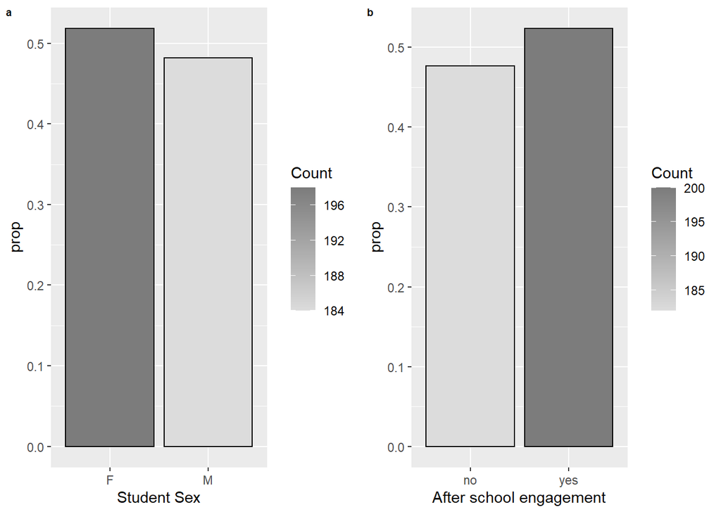

```r
############
# PART: Visualisation of categorical measurement statistics
############
plots <- list()

gs <- tbl_sactivity_sex_diff %>%
  ggplot(aes(x = sex))
gs <- gs + labs(x = 'Student Sex')
gs <- gs + geom_bar( colour = "black", aes(y = ..prop.., group =1, fill = ..count..))
gs <- gs + scale_fill_gradient("Count", low = "#DCDCDC", high = "#7C7C7C")
plots[["sex"]] <- gs

gs <- tbl_sactivity_sex_diff %>%
  ggplot(aes(x = activities.p))
gs <- gs + labs(x = 'After school engagement')
gs <- gs + geom_bar( colour = "black", aes(y = ..prop.., group =1, fill = ..count..))
gs <- gs + scale_fill_gradient("Count", low = "#DCDCDC", high = "#7C7C7C")
plots[["activity"]] <- gs


plot_grid(plotlist = plots,
          labels   = "auto",
          ncol = 2,
          align = 'h', hjust = -1.0, vjust = 2, label_size=7
)
```

## Step 2: Run Chi Square test

```r
############
# PART: Chi
############

# -------------- Conduct the Chi-Square --------------- #
#Use the Crosstable function
#CrossTable(predictor, outcome, fisher = TRUE, chisq = TRUE, expected = TRUE)
gmodels::CrossTable(tbl_sactivity_sex_diff$sex, tbl_sactivity_sex_diff$activities.p, fisher = TRUE, chisq = TRUE, expected = TRUE, sresid = TRUE, format = "SPSS")
```

```
##
##    Cell Contents
## |-------------------------|
## |                   Count |
## |         Expected Values |
## | Chi-square contribution |
## |             Row Percent |
## |          Column Percent |
## |           Total Percent |
## |            Std Residual |
## |-------------------------|
##
## Total Observations in Table:  382
##
##                            | tbl_sactivity_sex_diff$activities.p
## tbl_sactivity_sex_diff$sex |       no  |      yes  | Row Total |
## ---------------------------|-----------|-----------|-----------|
##                          F |      105  |       93  |      198  |
##                            |   94.335  |  103.665  |           |
##                            |    1.206  |    1.097  |           |
##                            |   53.030% |   46.970% |   51.832% |
##                            |   57.692% |   46.500% |           |
##                            |   27.487% |   24.346% |           |
##                            |    1.098  |   -1.047  |           |
## ---------------------------|-----------|-----------|-----------|
##                          M |       77  |      107  |      184  |
##                            |   87.665  |   96.335  |           |
##                            |    1.297  |    1.181  |           |
##                            |   41.848% |   58.152% |   48.168% |
##                            |   42.308% |   53.500% |           |
##                            |   20.157% |   28.010% |           |
##                            |   -1.139  |    1.087  |           |
## ---------------------------|-----------|-----------|-----------|
##               Column Total |      182  |      200  |      382  |
##                            |   47.644% |   52.356% |           |
## ---------------------------|-----------|-----------|-----------|
##
##
## Statistics for All Table Factors
##
```

[output cut: 14 more lines]

```
## Alternative hypothesis: true odds ratio is not equal to 1
## p =  0.03160227
## 95% confidence interval:  1.02609 2.39997
##
## Alternative hypothesis: true odds ratio is less than 1
## p =  0.9890319
## 95% confidence interval:  0 2.24789
##
## Alternative hypothesis: true odds ratio is greater than 1
## p =  0.01849912
## 95% confidence interval:  1.094444 Inf
##
##
##
##        Minimum expected frequency: 87.66492
```

```r
#more simplistic way of doing Chi-Square

#Create your contingency table
contingency_table <-xtabs(~activities.p+sex, data=tbl_sactivity_sex_diff)

ctest_test_result <-stats::chisq.test(contingency_table, correct=TRUE)#chi square test
#correct=TRUE to get Yates correction needed for 2x2 table

# -------------- Calculate the effect Size --------------- #
ctest_test_result$chi_effphi <- sjstats::phi(contingency_table)
ctest_test_result$chi_effcramer <- sjstats::cramer(contingency_table)

print.listof(ctest_test_result)
```

```
## statistic :
## X-squared
##  4.343239
##
## parameter :
## df
##  1
##
## p.value :
## [1] 0.03715617
##
## method :
## [1] "Pearson's Chi-squared test with Yates' continuity correction"
##
## data.name :
## [1] "contingency_table"
##
## observed :
##             sex
## activities.p   F   M
##          no  105  77
##          yes  93 107
##
## expected :
##             sex
## activities.p         F        M
##          no   94.33508 87.66492
##          yes 103.66492 96.33508
##
## residuals :
##             sex
## activities.p         F         M
##          no   1.098047 -1.139055
##          yes -1.047470  1.086589
##
## stdres :
##             sex
## activities.p         F         M
##          no   2.186556 -2.186556
##          yes -2.186556  2.186556
##
## chi_effphi :
## [1] 0.1118739
##
## chi_effcramer :
## [1] 0.1118739
```

## Reporting the results with effect size

A Chi-Square test for independence (with Yates’ Continuity Correction) indicated a significant association between gender and reported participation in after school activity, χ2(1,n=382) = 4.34 , p < .05, phi = .11). As such we reject the null hypothesis and accept the alternative hypotheses that there is a differential effect in after school activity engagement between male and female students. The odds of attending after school activities where 1.56 times higher for males students compared to female students.

# Repeated measures test for nominal variables.

So far we have only looked at tests for independent groups, but as mentioned there is another test type for related samples and that is a repeated measures test. This is where we have the same grouping but we take two measurements, the first at time T1 and the second at time T2 where T2 > T1. If our data measurement level is at interval data and normally distributed then we can use paired samples t-test. If the data is not normally distributed or ordinal we will use a Wilcoxon test if our data is nominal with two groups we use McNemar’s test, and lastly for multiple groups we use the Friedman Anova.

McNemar’s test is used to determine if there are differences on a binary dependent variable between two related groups. It can be considered to be similar to the paired-samples t-test, but for a binary nominal variable rather than a continuous scale variable. If we had more than two repeated measurements of the nominal variable, we could use Cochran’s Q test.

## Repeated Measures Nominal difference using Chi-Square and McNemar

As mentioned, students where asked twice about there engagement in after school activities with a time difference between each survey.

> HA: There are differences between extra-curricular activities engagement for respondents between measurements.

Using our student performance dataset we are going to investigate if there is a significant difference in extra-curricular activities engagement for students between measurements. We have one binary categorical variables, after school activity participation measured twice (activities.p, activities.m) . Due to how the demographic survey was administered there are two variables in the dataset capturing after school activity participation, one collected during Maths class and the other collected during the Portuguesse class at different times, as such it is valid for the same student to have different responses to the question and their circumstances may have changed between surveys. We will use the McNemar test to determine whether the proportion of participants who participated in after school activities (as opposed to those who did not) was different when comparing the first survey to the second survey result. This will provide supporting evidence to justify accepting omitting differences between survey responses for the this variable in our predictive model. As such our goal is to not find a significance result. An inspection of that data revealed that only 5 records contained difference response for the variable activities.p versus activities.m. As such we do not expect to find a significant result, but have included this test for the purposes of illustrating Repeated measures Nominal difference evaluation using Chi-Square and McNemar’s test.

## Step 1: Generate summary statistics

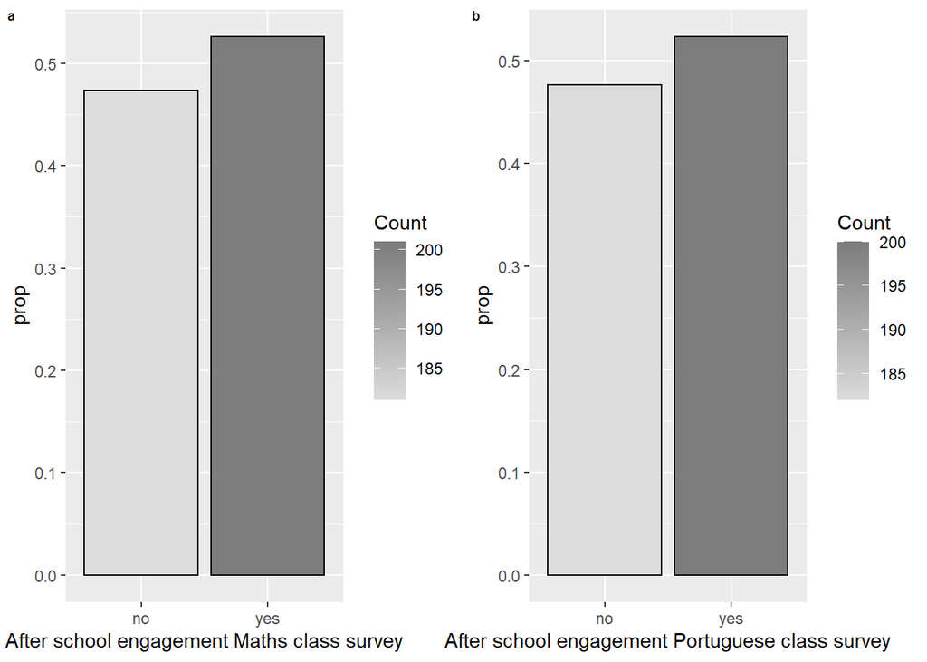

```r
############
# PART: Generate summary statistics
############

# Create a subset dataframe with just the variables of interest.
tbl_sactivity_diff <- tbl_sperf_all %>%
  select(contains('activities'))
# -------------- Create summary statistics --------------- #
tbl_sactivity_diff_stats <- tbl_sactivity_diff %>%
 summarytools::freq()

############
# PART: Visualisation of categorical measurement statistics
############
plots <- list()

gs <- tbl_sactivity_diff %>%
  ggplot(aes(x = activities.m))
gs <- gs + labs(x = 'After school engagement Maths class survey')
gs <- gs + geom_bar( colour = "black", aes(y = ..prop.., group =1, fill = ..count..))
gs <- gs + scale_fill_gradient("Count", low = "#DCDCDC", high = "#7C7C7C")
plots[["activities.m"]] <- gs

gs <- tbl_sactivity_diff %>%
  ggplot(aes(x = activities.p))
gs <- gs + labs(x = 'After school engagement Portuguese class survey')
gs <- gs + geom_bar( colour = "black", aes(y = ..prop.., group =1, fill = ..count..))
gs <- gs + scale_fill_gradient("Count", low = "#DCDCDC", high = "#7C7C7C")
plots[["activities.p"]] <- gs

plot_grid(plotlist = plots,
          labels   = "auto",
          ncol = 2,
          align = 'h', hjust = -1.0, vjust = 2, label_size=7
)
```

## Step 2: Run McNemar’s chi-squared test

```r
############
# PART: mcnemar = TRUE
############

# -------------- Conduct the Chi-Square with mcnemar = TRUE --------------- #
#Use the Crosstable function
#CrossTable(predictor, outcome, fisher = TRUE, chisq = TRUE, expected = TRUE, mcnemar = TRUE)
gmodels::CrossTable(tbl_sactivity_diff$activities.m, tbl_sactivity_diff$activities.p, mcnemar = TRUE, expected = TRUE, sresid = TRUE, prop.chisq = FALSE, format = "SPSS")
```

```
##
##    Cell Contents
## |-------------------------|
## |                   Count |
## |         Expected Values |
## |             Row Percent |
## |          Column Percent |
## |           Total Percent |
## |            Std Residual |
## |-------------------------|
##
## Total Observations in Table:  382
##
##                                 | tbl_sactivity_diff$activities.p
## tbl_sactivity_diff$activities.m |       no  |      yes  | Row Total |
## --------------------------------|-----------|-----------|-----------|
##                              no |      179  |        2  |      181  |
##                                 |   86.236  |   94.764  |           |
##                                 |   98.895% |    1.105% |   47.382% |
##                                 |   98.352% |    1.000% |           |
##                                 |   46.859% |    0.524% |           |
##                                 |    9.989  |   -9.529  |           |
## --------------------------------|-----------|-----------|-----------|
##                             yes |        3  |      198  |      201  |
##                                 |   95.764  |  105.236  |           |
##                                 |    1.493% |   98.507% |   52.618% |
##                                 |    1.648% |   99.000% |           |
##                                 |    0.785% |   51.832% |           |
##                                 |   -9.479  |    9.043  |           |
## --------------------------------|-----------|-----------|-----------|
##                    Column Total |      182  |      200  |      382  |
##                                 |   47.644% |   52.356% |           |
## --------------------------------|-----------|-----------|-----------|
##
##
## Statistics for All Table Factors
##
##
## Pearson's Chi-squared test
## ------------------------------------------------------------
## Chi^2 =  362.2236     d.f. =  1     p =  9.23437e-81
##
## Pearson's Chi-squared test with Yates' continuity correction
## ------------------------------------------------------------
## Chi^2 =  358.3293     d.f. =  1     p =  6.506784e-80
##
##
## McNemar's Chi-squared test
## ------------------------------------------------------------
## Chi^2 =  0.2     d.f. =  1     p =  0.6547208
##
## McNemar's Chi-squared test with continuity correction
## ------------------------------------------------------------
## Chi^2 =  0     d.f. =  1     p =  1
##
##
##        Minimum expected frequency: 86.2356
```

```r
#more simplistic way of doing Chi-Square

#Create your contingency table
contingency_table <-xtabs(~activities.p+activities.m, data=tbl_sactivity_diff)

ctest_test_result <-stats::mcnemar.test(contingency_table, correct=TRUE) #mcnemar
#correct=TRUE to get Yates correction needed for 2x2 table

# -------------- Calculate the effect Size --------------- #
ctest_test_result$chi_effphi <- sjstats::phi(contingency_table)
ctest_test_result$chi_effcramer <- sjstats::cramer(contingency_table)

print.listof(ctest_test_result)
```

```
## statistic :
## McNemar's chi-squared
##                     0
##
## parameter :
## df
##  1
##
## p.value :
## [1] 1
##
## method :
## [1] "McNemar's Chi-squared test with continuity correction"
##
## data.name :
## [1] "contingency_table"
##
## chi_effphi :
## [1] 0.9737707
##
## chi_effcramer :
## [1] 0.9737707
```

## Reporting the results with effect size

A McNemar’s chi-squared repeated measures test for difference (with Continuity Correction) indicated a no significant change in after school activity, χ2(1,n=382) = 0 , p = 1, phi = .97). As such we accept the null hypothesis and accept the reject the alternative hypotheses that there is a differential effect in after school activity engagement between repeated measures. The odds of attending after school activities where the same between measures for students.